# Risk Factor Analysis

## Outcome Variable

**Outcome Variable:** ever_stunted

## Predictor Variables

**Intervention Variable:** mage

**Adjustment Set:**

- arm
- meducyrs
- feducyrs
- W_mhtcm
- W_mwtkg
- W_mbmi
- single
- delta_meducyrs
- delta_feducyrs
- delta_W_mhtcm
- delta_W_mwtkg
- delta_W_mbmi
- delta_single

## Stratifying Variables

The analysis was stratified on these variable(s):

- agecat
- studyid
- country

## Data Summary

| agecat | studyid | country | mage | ever_stunted | n_cell | n |
| --- | --- | --- | --- | --- | --- | --- |
| 0-24 months | ki0047075b-MAL-ED | BANGLADESH | [20-30) | 0 | 77 | 265 |
| 0-24 months | ki0047075b-MAL-ED | BANGLADESH | [20-30) | 1 | 105 | 265 |
| 0-24 months | ki0047075b-MAL-ED | BANGLADESH | <20 | 0 | 8 | 265 |
| 0-24 months | ki0047075b-MAL-ED | BANGLADESH | <20 | 1 | 29 | 265 |
| 0-24 months | ki0047075b-MAL-ED | BANGLADESH | >=30 | 0 | 18 | 265 |
| 0-24 months | ki0047075b-MAL-ED | BANGLADESH | >=30 | 1 | 28 | 265 |
| 0-24 months | ki0047075b-MAL-ED | BRAZIL | [20-30) | 0 | 99 | 233 |
| 0-24 months | ki0047075b-MAL-ED | BRAZIL | [20-30) | 1 | 40 | 233 |
| 0-24 months | ki0047075b-MAL-ED | BRAZIL | <20 | 0 | 32 | 233 |
| 0-24 months | ki0047075b-MAL-ED | BRAZIL | <20 | 1 | 11 | 233 |
| 0-24 months | ki0047075b-MAL-ED | BRAZIL | >=30 | 0 | 39 | 233 |
| 0-24 months | ki0047075b-MAL-ED | BRAZIL | >=30 | 1 | 12 | 233 |
| 0-24 months | ki0047075b-MAL-ED | INDIA | [20-30) | 0 | 75 | 249 |
| 0-24 months | ki0047075b-MAL-ED | INDIA | [20-30) | 1 | 119 | 249 |
| 0-24 months | ki0047075b-MAL-ED | INDIA | <20 | 0 | 13 | 249 |
| 0-24 months | ki0047075b-MAL-ED | INDIA | <20 | 1 | 21 | 249 |
| 0-24 months | ki0047075b-MAL-ED | INDIA | >=30 | 0 | 11 | 249 |
| 0-24 months | ki0047075b-MAL-ED | INDIA | >=30 | 1 | 10 | 249 |
| 0-24 months | ki0047075b-MAL-ED | NEPAL | [20-30) | 0 | 126 | 240 |
| 0-24 months | ki0047075b-MAL-ED | NEPAL | [20-30) | 1 | 63 | 240 |
| 0-24 months | ki0047075b-MAL-ED | NEPAL | <20 | 0 | 2 | 240 |
| 0-24 months | ki0047075b-MAL-ED | NEPAL | <20 | 1 | 3 | 240 |
| 0-24 months | ki0047075b-MAL-ED | NEPAL | >=30 | 0 | 28 | 240 |
| 0-24 months | ki0047075b-MAL-ED | NEPAL | >=30 | 1 | 18 | 240 |
| 0-24 months | ki0047075b-MAL-ED | PERU | [20-30) | 0 | 61 | 303 |
| 0-24 months | ki0047075b-MAL-ED | PERU | [20-30) | 1 | 92 | 303 |
| 0-24 months | ki0047075b-MAL-ED | PERU | <20 | 0 | 29 | 303 |
| 0-24 months | ki0047075b-MAL-ED | PERU | <20 | 1 | 54 | 303 |
| 0-24 months | ki0047075b-MAL-ED | PERU | >=30 | 0 | 25 | 303 |
| 0-24 months | ki0047075b-MAL-ED | PERU | >=30 | 1 | 42 | 303 |

[output cut: 450 more lines]

The following strata were considered:

- agecat: 0-24 months, studyid: ki0047075b-MAL-ED, country: BANGLADESH
- agecat: 0-24 months, studyid: ki0047075b-MAL-ED, country: BRAZIL
- agecat: 0-24 months, studyid: ki0047075b-MAL-ED, country: INDIA
- agecat: 0-24 months, studyid: ki0047075b-MAL-ED, country: NEPAL
- agecat: 0-24 months, studyid: ki0047075b-MAL-ED, country: PERU
- agecat: 0-24 months, studyid: ki0047075b-MAL-ED, country: SOUTH AFRICA
- agecat: 0-24 months, studyid: ki0047075b-MAL-ED, country: TANZANIA, UNITED REPUBLIC OF
- agecat: 0-24 months, studyid: ki1000108-CMC-V-BCS-2002, country: INDIA
- agecat: 0-24 months, studyid: ki1000108-IRC, country: INDIA
- agecat: 0-24 months, studyid: ki1000109-EE, country: PAKISTAN
- agecat: 0-24 months, studyid: ki1000304b-SAS-CompFeed, country: INDIA
- agecat: 0-24 months, studyid: ki1000304b-SAS-FoodSuppl, country: INDIA
- agecat: 0-24 months, studyid: ki1017093-NIH-Birth, country: BANGLADESH
- agecat: 0-24 months, studyid: ki1017093b-PROVIDE, country: BANGLADESH
- agecat: 0-24 months, studyid: ki1017093c-NIH-Crypto, country: BANGLADESH
- agecat: 0-24 months, studyid: ki1066203-TanzaniaChild2, country: TANZANIA, UNITED REPUBLIC OF
- agecat: 0-24 months, studyid: ki1101329-Keneba, country: GAMBIA
- agecat: 0-24 months, studyid: ki1112895-Guatemala BSC, country: GUATEMALA
- agecat: 0-24 months, studyid: ki1112895-iLiNS-Zinc, country: BURKINA FASO
- agecat: 0-24 months, studyid: ki1113344-GMS-Nepal, country: NEPAL
- agecat: 0-24 months, studyid: ki1119695-PROBIT, country: BELARUS
- agecat: 0-24 months, studyid: ki1126311-ZVITAMBO, country: ZIMBABWE
- agecat: 0-24 months, studyid: ki1135781-COHORTS, country: GUATEMALA
- agecat: 0-24 months, studyid: ki1135781-COHORTS, country: INDIA
- agecat: 0-24 months, studyid: ki1135781-COHORTS, country: PHILIPPINES
- agecat: 0-24 months, studyid: ki1148112-LCNI-5, country: MALAWI
- agecat: 0-24 months, studyid: kiGH5241-JiVitA-3, country: BANGLADESH
- agecat: 0-6 months, studyid: ki0047075b-MAL-ED, country: BANGLADESH
- agecat: 0-6 months, studyid: ki0047075b-MAL-ED, country: BRAZIL
- agecat: 0-6 months, studyid: ki0047075b-MAL-ED, country: INDIA
- agecat: 0-6 months, studyid: ki0047075b-MAL-ED, country: NEPAL
- agecat: 0-6 months, studyid: ki0047075b-MAL-ED, country: PERU
- agecat: 0-6 months, studyid: ki0047075b-MAL-ED, country: SOUTH AFRICA
- agecat: 0-6 months, studyid: ki0047075b-MAL-ED, country: TANZANIA, UNITED REPUBLIC OF
- agecat: 0-6 months, studyid: ki1000108-CMC-V-BCS-2002, country: INDIA
- agecat: 0-6 months, studyid: ki1000108-IRC, country: INDIA
- agecat: 0-6 months, studyid: ki1000109-EE, country: PAKISTAN
- agecat: 0-6 months, studyid: ki1000304b-SAS-CompFeed, country: INDIA
- agecat: 0-6 months, studyid: ki1000304b-SAS-FoodSuppl, country: INDIA
- agecat: 0-6 months, studyid: ki1017093-NIH-Birth, country: BANGLADESH
- agecat: 0-6 months, studyid: ki1017093b-PROVIDE, country: BANGLADESH
- agecat: 0-6 months, studyid: ki1017093c-NIH-Crypto, country: BANGLADESH
- agecat: 0-6 months, studyid: ki1066203-TanzaniaChild2, country: TANZANIA, UNITED REPUBLIC OF
- agecat: 0-6 months, studyid: ki1101329-Keneba, country: GAMBIA
- agecat: 0-6 months, studyid: ki1112895-Guatemala BSC, country: GUATEMALA
- agecat: 0-6 months, studyid: ki1113344-GMS-Nepal, country: NEPAL
- agecat: 0-6 months, studyid: ki1119695-PROBIT, country: BELARUS
- agecat: 0-6 months, studyid: ki1126311-ZVITAMBO, country: ZIMBABWE
- agecat: 0-6 months, studyid: ki1135781-COHORTS, country: GUATEMALA
- agecat: 0-6 months, studyid: ki1135781-COHORTS, country: INDIA
- agecat: 0-6 months, studyid: ki1135781-COHORTS, country: PHILIPPINES
- agecat: 0-6 months, studyid: ki1148112-LCNI-5, country: MALAWI
- agecat: 0-6 months, studyid: kiGH5241-JiVitA-3, country: BANGLADESH
- agecat: 6-24 months, studyid: ki0047075b-MAL-ED, country: BANGLADESH
- agecat: 6-24 months, studyid: ki0047075b-MAL-ED, country: BRAZIL
- agecat: 6-24 months, studyid: ki0047075b-MAL-ED, country: INDIA
- agecat: 6-24 months, studyid: ki0047075b-MAL-ED, country: NEPAL
- agecat: 6-24 months, studyid: ki0047075b-MAL-ED, country: PERU
- agecat: 6-24 months, studyid: ki0047075b-MAL-ED, country: SOUTH AFRICA
- agecat: 6-24 months, studyid: ki0047075b-MAL-ED, country: TANZANIA, UNITED REPUBLIC OF
- agecat: 6-24 months, studyid: ki1000108-CMC-V-BCS-2002, country: INDIA
- agecat: 6-24 months, studyid: ki1000108-IRC, country: INDIA
- agecat: 6-24 months, studyid: ki1000109-EE, country: PAKISTAN
- agecat: 6-24 months, studyid: ki1000304b-SAS-CompFeed, country: INDIA
- agecat: 6-24 months, studyid: ki1000304b-SAS-FoodSuppl, country: INDIA
- agecat: 6-24 months, studyid: ki1017093-NIH-Birth, country: BANGLADESH
- agecat: 6-24 months, studyid: ki1017093b-PROVIDE, country: BANGLADESH
- agecat: 6-24 months, studyid: ki1017093c-NIH-Crypto, country: BANGLADESH
- agecat: 6-24 months, studyid: ki1066203-TanzaniaChild2, country: TANZANIA, UNITED REPUBLIC OF
- agecat: 6-24 months, studyid: ki1101329-Keneba, country: GAMBIA
- agecat: 6-24 months, studyid: ki1112895-Guatemala BSC, country: GUATEMALA
- agecat: 6-24 months, studyid: ki1112895-iLiNS-Zinc, country: BURKINA FASO
- agecat: 6-24 months, studyid: ki1113344-GMS-Nepal, country: NEPAL
- agecat: 6-24 months, studyid: ki1119695-PROBIT, country: BELARUS
- agecat: 6-24 months, studyid: ki1126311-ZVITAMBO, country: ZIMBABWE
- agecat: 6-24 months, studyid: ki1135781-COHORTS, country: GUATEMALA
- agecat: 6-24 months, studyid: ki1135781-COHORTS, country: INDIA
- agecat: 6-24 months, studyid: ki1135781-COHORTS, country: PHILIPPINES
- agecat: 6-24 months, studyid: ki1148112-LCNI-5, country: MALAWI
- agecat: 6-24 months, studyid: kiGH5241-JiVitA-3, country: BANGLADESH

### Dropped Strata

Some strata were dropped due to rare outcomes:

- agecat: 0-24 months, studyid: ki0047075b-MAL-ED, country: NEPAL
- agecat: 0-24 months, studyid: ki0047075b-MAL-ED, country: TANZANIA, UNITED REPUBLIC OF
- agecat: 0-24 months, studyid: ki1000108-CMC-V-BCS-2002, country: INDIA
- agecat: 0-24 months, studyid: ki1000109-EE, country: PAKISTAN
- agecat: 0-6 months, studyid: ki0047075b-MAL-ED, country: INDIA
- agecat: 0-6 months, studyid: ki0047075b-MAL-ED, country: NEPAL
- agecat: 0-6 months, studyid: ki1000109-EE, country: PAKISTAN
- agecat: 6-24 months, studyid: ki0047075b-MAL-ED, country: BRAZIL
- agecat: 6-24 months, studyid: ki0047075b-MAL-ED, country: NEPAL
- agecat: 6-24 months, studyid: ki0047075b-MAL-ED, country: TANZANIA, UNITED REPUBLIC OF
- agecat: 6-24 months, studyid: ki1000108-CMC-V-BCS-2002, country: INDIA
- agecat: 6-24 months, studyid: ki1000108-IRC, country: INDIA
- agecat: 6-24 months, studyid: ki1000109-EE, country: PAKISTAN

## Methods Detail

We’re interested in the causal parameters $E[Y_a]$ for all values of $a \in \mathcal{A}$. These parameters represent the mean outcome if, possibly contrary to fact, we intervened to set all units to have $A=a$. Under the randomization and positivity assumptions, these are identified by the statistical parameters $\psi_a=E_W[E_{Y|A,W}(Y|A=a,W)]$. In addition, we’re interested in the mean of $Y$, $E[Y]$ under no intervention (the observed mean). We will estimate these parameters by using SuperLearner to fit the relevant likelihood factors – $E_{Y|A,W}(Y|A=a,W)$ and $p(A=a|W)$, and then updating our likelihood fit using a joint TMLE.

For unadjusted analyses ($W=\{\}$), initial likelihoods were estimated using Lrnr_glm to estimate the simple $E(Y|A)$ and Lrnr_mean to estimate $p(A)$. For adjusted analyses, a small library containing Lrnr_glmnet, Lrnr_xgboost, and Lrnr_mean was used.

Having estimated these parameters, we will then use the delta method to estimate relative risks and attributable risks relative to a prespecified baseline level of $A$.

# Results Detail

## Results Plots

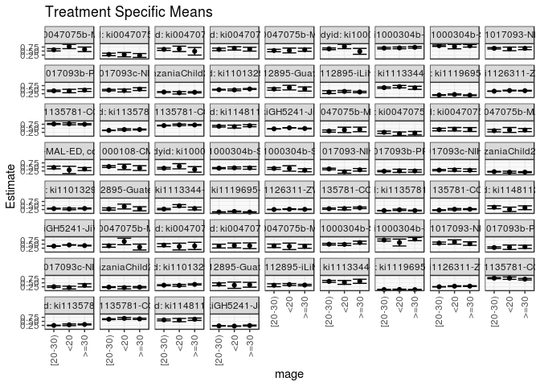

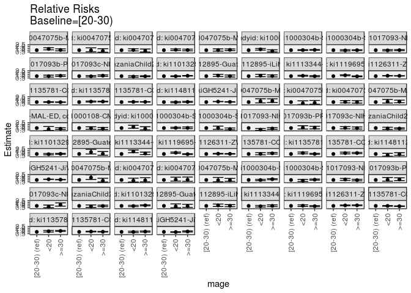

[figure not shown]

[figure not shown]

## Results Table

### Parameter: TSM

| agecat | studyid | country | intervention_level | baseline_level | estimate | ci_lower | ci_upper |
| --- | --- | --- | --- | --- | --- | --- | --- |
| 0-24 months | ki0047075b-MAL-ED | BANGLADESH | [20-30) | NA | 0.5769231 | 0.5050110 | 0.6488352 |
| 0-24 months | ki0047075b-MAL-ED | BANGLADESH | <20 | NA | 0.7837838 | 0.6508882 | 0.9166793 |
| 0-24 months | ki0047075b-MAL-ED | BANGLADESH | >=30 | NA | 0.6086957 | 0.4673939 | 0.7499974 |
| 0-24 months | ki0047075b-MAL-ED | BRAZIL | [20-30) | NA | 0.2895354 | 0.2112758 | 0.3677949 |
| 0-24 months | ki0047075b-MAL-ED | BRAZIL | <20 | NA | 0.2749576 | 0.1412443 | 0.4086708 |
| 0-24 months | ki0047075b-MAL-ED | BRAZIL | >=30 | NA | 0.2261104 | 0.1053102 | 0.3469105 |
| 0-24 months | ki0047075b-MAL-ED | INDIA | [20-30) | NA | 0.6077920 | 0.5395051 | 0.6760788 |
| 0-24 months | ki0047075b-MAL-ED | INDIA | <20 | NA | 0.6370166 | 0.4683146 | 0.8057186 |
| 0-24 months | ki0047075b-MAL-ED | INDIA | >=30 | NA | 0.4864515 | 0.2494134 | 0.7234895 |
| 0-24 months | ki0047075b-MAL-ED | PERU | [20-30) | NA | 0.6017960 | 0.5240107 | 0.6795813 |
| 0-24 months | ki0047075b-MAL-ED | PERU | <20 | NA | 0.6662858 | 0.5640618 | 0.7685098 |
| 0-24 months | ki0047075b-MAL-ED | PERU | >=30 | NA | 0.6167979 | 0.4977953 | 0.7358006 |
| 0-24 months | ki0047075b-MAL-ED | SOUTH AFRICA | [20-30) | NA | 0.5339121 | 0.4582421 | 0.6095822 |
| 0-24 months | ki0047075b-MAL-ED | SOUTH AFRICA | <20 | NA | 0.5363936 | 0.3878786 | 0.6849085 |
| 0-24 months | ki0047075b-MAL-ED | SOUTH AFRICA | >=30 | NA | 0.5841262 | 0.4888197 | 0.6794327 |
| 0-24 months | ki1000108-IRC | INDIA | [20-30) | NA | 0.6395349 | 0.5887350 | 0.6903348 |
| 0-24 months | ki1000108-IRC | INDIA | <20 | NA | 0.7837838 | 0.6509771 | 0.9165904 |
| 0-24 months | ki1000108-IRC | INDIA | >=30 | NA | 0.4827586 | 0.3006666 | 0.6648507 |
| 0-24 months | ki1000304b-SAS-CompFeed | INDIA | [20-30) | NA | 0.6844233 | 0.6352324 | 0.7336142 |
| 0-24 months | ki1000304b-SAS-CompFeed | INDIA | <20 | NA | 0.6970557 | 0.6428433 | 0.7512681 |
| 0-24 months | ki1000304b-SAS-CompFeed | INDIA | >=30 | NA | 0.7348340 | 0.6808510 | 0.7888170 |
| 0-24 months | ki1000304b-SAS-FoodSuppl | INDIA | [20-30) | NA | 0.8344828 | 0.7916575 | 0.8773080 |
| 0-24 months | ki1000304b-SAS-FoodSuppl | INDIA | <20 | NA | 0.7777778 | 0.6418092 | 0.9137463 |
| 0-24 months | ki1000304b-SAS-FoodSuppl | INDIA | >=30 | NA | 0.8260870 | 0.7485421 | 0.9036319 |
| 0-24 months | ki1017093-NIH-Birth | BANGLADESH | [20-30) | NA | 0.6720780 | 0.6276706 | 0.7164854 |
| 0-24 months | ki1017093-NIH-Birth | BANGLADESH | <20 | NA | 0.6350528 | 0.5240355 | 0.7460701 |
| 0-24 months | ki1017093-NIH-Birth | BANGLADESH | >=30 | NA | 0.6697578 | 0.5899563 | 0.7495593 |
| 0-24 months | ki1017093b-PROVIDE | BANGLADESH | [20-30) | NA | 0.4299279 | 0.3866163 | 0.4732396 |
| 0-24 months | ki1017093b-PROVIDE | BANGLADESH | <20 | NA | 0.4166644 | 0.3103549 | 0.5229739 |
| 0-24 months | ki1017093b-PROVIDE | BANGLADESH | >=30 | NA | 0.4743079 | 0.3901451 | 0.5584708 |

[output cut: 171 more lines]

### Parameter: E(Y)

| agecat | studyid | country | intervention_level | baseline_level | estimate | ci_lower | ci_upper |
| --- | --- | --- | --- | --- | --- | --- | --- |
| 0-24 months | ki0047075b-MAL-ED | BANGLADESH | NA | NA | 0.6113208 | 0.5525209 | 0.6701206 |
| 0-24 months | ki0047075b-MAL-ED | BRAZIL | NA | NA | 0.2703863 | 0.2132328 | 0.3275398 |
| 0-24 months | ki0047075b-MAL-ED | INDIA | NA | NA | 0.6024096 | 0.5415000 | 0.6633193 |
| 0-24 months | ki0047075b-MAL-ED | PERU | NA | NA | 0.6204620 | 0.5657315 | 0.6751926 |
| 0-24 months | ki0047075b-MAL-ED | SOUTH AFRICA | NA | NA | 0.5605096 | 0.5055248 | 0.6154943 |
| 0-24 months | ki1000108-IRC | INDIA | NA | NA | 0.6414634 | 0.5949863 | 0.6879405 |
| 0-24 months | ki1000304b-SAS-CompFeed | INDIA | NA | NA | 0.6914547 | 0.6510509 | 0.7318584 |
| 0-24 months | ki1000304b-SAS-FoodSuppl | INDIA | NA | NA | 0.8277512 | 0.7915095 | 0.8639929 |
| 0-24 months | ki1017093-NIH-Birth | BANGLADESH | NA | NA | 0.6634769 | 0.6264616 | 0.7004922 |
| 0-24 months | ki1017093b-PROVIDE | BANGLADESH | NA | NA | 0.4357143 | 0.3989556 | 0.4724730 |
| 0-24 months | ki1017093c-NIH-Crypto | BANGLADESH | NA | NA | 0.4775726 | 0.4419904 | 0.5131548 |
| 0-24 months | ki1066203-TanzaniaChild2 | TANZANIA, UNITED REPUBLIC OF | NA | NA | 0.3459596 | 0.3268289 | 0.3650903 |
| 0-24 months | ki1101329-Keneba | GAMBIA | NA | NA | 0.5183631 | 0.5000444 | 0.5366817 |
| 0-24 months | ki1112895-Guatemala BSC | GUATEMALA | NA | NA | 0.5551601 | 0.4969525 | 0.6133678 |
| 0-24 months | ki1112895-iLiNS-Zinc | BURKINA FASO | NA | NA | 0.3561989 | 0.3061990 | 0.4061987 |
| 0-24 months | ki1113344-GMS-Nepal | NEPAL | NA | NA | 0.6389685 | 0.6033115 | 0.6746254 |
| 0-24 months | ki1119695-PROBIT | BELARUS | NA | NA | 0.1674854 | 0.1488048 | 0.1861659 |
| 0-24 months | ki1126311-ZVITAMBO | ZIMBABWE | NA | NA | 0.4172011 | 0.4090427 | 0.4253595 |
| 0-24 months | ki1135781-COHORTS | GUATEMALA | NA | NA | 0.7639706 | 0.7413939 | 0.7865473 |
| 0-24 months | ki1135781-COHORTS | INDIA | NA | NA | 0.3877282 | 0.3746257 | 0.4008307 |
| 0-24 months | ki1135781-COHORTS | PHILIPPINES | NA | NA | 0.6863963 | 0.6699497 | 0.7028430 |
| 0-24 months | ki1148112-LCNI-5 | MALAWI | NA | NA | 0.6373134 | 0.6008819 | 0.6737450 |
| 0-24 months | kiGH5241-JiVitA-3 | BANGLADESH | NA | NA | 0.4952969 | 0.4874720 | 0.5031218 |
| 0-6 months | ki0047075b-MAL-ED | BANGLADESH | NA | NA | 0.3584906 | 0.3006428 | 0.4163383 |
| 0-6 months | ki0047075b-MAL-ED | BRAZIL | NA | NA | 0.2231760 | 0.1695976 | 0.2767543 |
| 0-6 months | ki0047075b-MAL-ED | PERU | NA | NA | 0.4257426 | 0.3699763 | 0.4815088 |
| 0-6 months | ki0047075b-MAL-ED | SOUTH AFRICA | NA | NA | 0.3694268 | 0.3159570 | 0.4228965 |
| 0-6 months | ki0047075b-MAL-ED | TANZANIA, UNITED REPUBLIC OF | NA | NA | 0.4160305 | 0.3562327 | 0.4758284 |
| 0-6 months | ki1000108-CMC-V-BCS-2002 | INDIA | NA | NA | 0.5108696 | 0.4597270 | 0.5620121 |
| 0-6 months | ki1000108-IRC | INDIA | NA | NA | 0.4243902 | 0.3764905 | 0.4722900 |
| 0-6 months | ki1000304b-SAS-CompFeed | INDIA | NA | NA | 0.4254902 | 0.3977202 | 0.4532601 |
| 0-6 months | ki1000304b-SAS-FoodSuppl | INDIA | NA | NA | 0.3894231 | 0.3425088 | 0.4363374 |
| 0-6 months | ki1017093-NIH-Birth | BANGLADESH | NA | NA | 0.3476874 | 0.3103810 | 0.3849938 |
| 0-6 months | ki1017093b-PROVIDE | BANGLADESH | NA | NA | 0.2400000 | 0.2083392 | 0.2716608 |
| 0-6 months | ki1017093c-NIH-Crypto | BANGLADESH | NA | NA | 0.3021108 | 0.2694011 | 0.3348205 |
| 0-6 months | ki1066203-TanzaniaChild2 | TANZANIA, UNITED REPUBLIC OF | NA | NA | 0.1944444 | 0.1785274 | 0.2103615 |
| 0-6 months | ki1101329-Keneba | GAMBIA | NA | NA | 0.3127302 | 0.2943427 | 0.3311178 |
| 0-6 months | ki1112895-Guatemala BSC | GUATEMALA | NA | NA | 0.3181818 | 0.2618904 | 0.3744732 |
| 0-6 months | ki1113344-GMS-Nepal | NEPAL | NA | NA | 0.3180516 | 0.2834770 | 0.3526261 |
| 0-6 months | ki1119695-PROBIT | BELARUS | NA | NA | 0.0995087 | 0.0864641 | 0.1125533 |
| 0-6 months | ki1126311-ZVITAMBO | ZIMBABWE | NA | NA | 0.2587572 | 0.2515068 | 0.2660076 |
| 0-6 months | ki1135781-COHORTS | GUATEMALA | NA | NA | 0.3253896 | 0.2975756 | 0.3532035 |
| 0-6 months | ki1135781-COHORTS | INDIA | NA | NA | 0.1902629 | 0.1795262 | 0.2009996 |
| 0-6 months | ki1135781-COHORTS | PHILIPPINES | NA | NA | 0.2390451 | 0.2239262 | 0.2541640 |
| 0-6 months | ki1148112-LCNI-5 | MALAWI | NA | NA | 0.3545455 | 0.2911884 | 0.4179025 |
| 0-6 months | kiGH5241-JiVitA-3 | BANGLADESH | NA | NA | 0.4129650 | 0.4055288 | 0.4204012 |
| 6-24 months | ki0047075b-MAL-ED | BANGLADESH | NA | NA | 0.4240506 | 0.3467471 | 0.5013542 |
| 6-24 months | ki0047075b-MAL-ED | INDIA | NA | NA | 0.4220779 | 0.3438191 | 0.5003367 |
| 6-24 months | ki0047075b-MAL-ED | PERU | NA | NA | 0.3959732 | 0.3171819 | 0.4747644 |
| 6-24 months | ki0047075b-MAL-ED | SOUTH AFRICA | NA | NA | 0.3797468 | 0.3038314 | 0.4556622 |
| 6-24 months | ki1000304b-SAS-CompFeed | INDIA | NA | NA | 0.5030750 | 0.4588491 | 0.5473009 |
| 6-24 months | ki1000304b-SAS-FoodSuppl | INDIA | NA | NA | 0.7572016 | 0.7031798 | 0.8112234 |
| 6-24 months | ki1017093-NIH-Birth | BANGLADESH | NA | NA | 0.5739130 | 0.5216565 | 0.6261696 |
| 6-24 months | ki1017093b-PROVIDE | BANGLADESH | NA | NA | 0.3004386 | 0.2583143 | 0.3425629 |
| 6-24 months | ki1017093c-NIH-Crypto | BANGLADESH | NA | NA | 0.2628458 | 0.2244546 | 0.3012371 |
| 6-24 months | ki1066203-TanzaniaChild2 | TANZANIA, UNITED REPUBLIC OF | NA | NA | 0.2262728 | 0.2057063 | 0.2468392 |
| 6-24 months | ki1101329-Keneba | GAMBIA | NA | NA | 0.3640974 | 0.3428547 | 0.3853400 |
| 6-24 months | ki1112895-Guatemala BSC | GUATEMALA | NA | NA | 0.3913043 | 0.3205945 | 0.4620142 |
| 6-24 months | ki1112895-iLiNS-Zinc | BURKINA FASO | NA | NA | 0.3561989 | 0.3061990 | 0.4061987 |
| 6-24 months | ki1113344-GMS-Nepal | NEPAL | NA | NA | 0.5642317 | 0.5153938 | 0.6130696 |
| 6-24 months | ki1119695-PROBIT | BELARUS | NA | NA | 0.0768510 | 0.0628857 | 0.0908164 |
| 6-24 months | ki1126311-ZVITAMBO | ZIMBABWE | NA | NA | 0.2628598 | 0.2534882 | 0.2722315 |
| 6-24 months | ki1135781-COHORTS | GUATEMALA | NA | NA | 0.7642458 | 0.7364214 | 0.7920702 |
| 6-24 months | ki1135781-COHORTS | INDIA | NA | NA | 0.2666174 | 0.2530174 | 0.2802175 |
| 6-24 months | ki1135781-COHORTS | PHILIPPINES | NA | NA | 0.6449788 | 0.6246093 | 0.6653483 |
| 6-24 months | ki1148112-LCNI-5 | MALAWI | NA | NA | 0.6006885 | 0.5608305 | 0.6405464 |
| 6-24 months | kiGH5241-JiVitA-3 | BANGLADESH | NA | NA | 0.2162471 | 0.2068695 | 0.2256248 |

### Parameter: RR

| agecat | studyid | country | intervention_level | baseline_level | estimate | ci_lower | ci_upper |
| --- | --- | --- | --- | --- | --- | --- | --- |
| 0-24 months | ki0047075b-MAL-ED | BANGLADESH | [20-30) | [20-30) | 1.0000000 | 1.0000000 | 1.0000000 |
| 0-24 months | ki0047075b-MAL-ED | BANGLADESH | <20 | [20-30) | 1.3585586 | 1.1007380 | 1.6767671 |
| 0-24 months | ki0047075b-MAL-ED | BANGLADESH | >=30 | [20-30) | 1.0550725 | 0.8106836 | 1.3731349 |
| 0-24 months | ki0047075b-MAL-ED | BRAZIL | [20-30) | [20-30) | 1.0000000 | 1.0000000 | 1.0000000 |
| 0-24 months | ki0047075b-MAL-ED | BRAZIL | <20 | [20-30) | 0.9496510 | 0.5437165 | 1.6586530 |
| 0-24 months | ki0047075b-MAL-ED | BRAZIL | >=30 | [20-30) | 0.7809422 | 0.4289131 | 1.4218980 |
| 0-24 months | ki0047075b-MAL-ED | INDIA | [20-30) | [20-30) | 1.0000000 | 1.0000000 | 1.0000000 |
| 0-24 months | ki0047075b-MAL-ED | INDIA | <20 | [20-30) | 1.0480833 | 0.7878401 | 1.3942913 |
| 0-24 months | ki0047075b-MAL-ED | INDIA | >=30 | [20-30) | 0.8003585 | 0.4854517 | 1.3195415 |
| 0-24 months | ki0047075b-MAL-ED | PERU | [20-30) | [20-30) | 1.0000000 | 1.0000000 | 1.0000000 |
| 0-24 months | ki0047075b-MAL-ED | PERU | <20 | [20-30) | 1.1071622 | 0.9073880 | 1.3509196 |
| 0-24 months | ki0047075b-MAL-ED | PERU | >=30 | [20-30) | 1.0249286 | 0.8131724 | 1.2918278 |
| 0-24 months | ki0047075b-MAL-ED | SOUTH AFRICA | [20-30) | [20-30) | 1.0000000 | 1.0000000 | 1.0000000 |
| 0-24 months | ki0047075b-MAL-ED | SOUTH AFRICA | <20 | [20-30) | 1.0046477 | 0.7377730 | 1.3680588 |
| 0-24 months | ki0047075b-MAL-ED | SOUTH AFRICA | >=30 | [20-30) | 1.0940493 | 0.8846029 | 1.3530861 |
| 0-24 months | ki1000108-IRC | INDIA | [20-30) | [20-30) | 1.0000000 | 1.0000000 | 1.0000000 |
| 0-24 months | ki1000108-IRC | INDIA | <20 | [20-30) | 1.2255528 | 1.0163873 | 1.4777631 |
| 0-24 months | ki1000108-IRC | INDIA | >=30 | [20-30) | 0.7548589 | 0.5134061 | 1.1098662 |
| 0-24 months | ki1000304b-SAS-CompFeed | INDIA | [20-30) | [20-30) | 1.0000000 | 1.0000000 | 1.0000000 |
| 0-24 months | ki1000304b-SAS-CompFeed | INDIA | <20 | [20-30) | 1.0184570 | 0.9188774 | 1.1288282 |
| 0-24 months | ki1000304b-SAS-CompFeed | INDIA | >=30 | [20-30) | 1.0736542 | 0.9867444 | 1.1682188 |
| 0-24 months | ki1000304b-SAS-FoodSuppl | INDIA | [20-30) | [20-30) | 1.0000000 | 1.0000000 | 1.0000000 |
| 0-24 months | ki1000304b-SAS-FoodSuppl | INDIA | <20 | [20-30) | 0.9320478 | 0.7768057 | 1.1183144 |
| 0-24 months | ki1000304b-SAS-FoodSuppl | INDIA | >=30 | [20-30) | 0.9899389 | 0.8895009 | 1.1017178 |
| 0-24 months | ki1017093-NIH-Birth | BANGLADESH | [20-30) | [20-30) | 1.0000000 | 1.0000000 | 1.0000000 |
| 0-24 months | ki1017093-NIH-Birth | BANGLADESH | <20 | [20-30) | 0.9449094 | 0.7850335 | 1.1373449 |
| 0-24 months | ki1017093-NIH-Birth | BANGLADESH | >=30 | [20-30) | 0.9965477 | 0.8707627 | 1.1405029 |
| 0-24 months | ki1017093b-PROVIDE | BANGLADESH | [20-30) | [20-30) | 1.0000000 | 1.0000000 | 1.0000000 |
| 0-24 months | ki1017093b-PROVIDE | BANGLADESH | <20 | [20-30) | 0.9691494 | 0.7382090 | 1.2723371 |
| 0-24 months | ki1017093b-PROVIDE | BANGLADESH | >=30 | [20-30) | 1.1032266 | 0.9031705 | 1.3475959 |

[output cut: 171 more lines]

### Parameter: PAR

| agecat | studyid | country | intervention_level | baseline_level | estimate | ci_lower | ci_upper |
| --- | --- | --- | --- | --- | --- | --- | --- |
| 0-24 months | ki0047075b-MAL-ED | BANGLADESH | [20-30) | NA | 0.0343977 | -0.0046598 | 0.0734552 |
| 0-24 months | ki0047075b-MAL-ED | BRAZIL | [20-30) | NA | -0.0191491 | -0.0680762 | 0.0297780 |
| 0-24 months | ki0047075b-MAL-ED | INDIA | [20-30) | NA | -0.0053823 | -0.0380607 | 0.0272961 |
| 0-24 months | ki0047075b-MAL-ED | PERU | [20-30) | NA | 0.0186661 | -0.0353970 | 0.0727291 |
| 0-24 months | ki0047075b-MAL-ED | SOUTH AFRICA | [20-30) | NA | 0.0265974 | -0.0253101 | 0.0785049 |
| 0-24 months | ki1000108-IRC | INDIA | [20-30) | NA | 0.0019285 | -0.0183280 | 0.0221851 |
| 0-24 months | ki1000304b-SAS-CompFeed | INDIA | [20-30) | NA | 0.0070313 | -0.0069748 | 0.0210375 |
| 0-24 months | ki1000304b-SAS-FoodSuppl | INDIA | [20-30) | NA | -0.0067316 | -0.0312810 | 0.0178179 |
| 0-24 months | ki1017093-NIH-Birth | BANGLADESH | [20-30) | NA | -0.0086011 | -0.0338614 | 0.0166592 |
| 0-24 months | ki1017093b-PROVIDE | BANGLADESH | [20-30) | NA | 0.0057863 | -0.0169003 | 0.0284730 |
| 0-24 months | ki1017093c-NIH-Crypto | BANGLADESH | [20-30) | NA | 0.0040655 | -0.0218818 | 0.0300128 |
| 0-24 months | ki1066203-TanzaniaChild2 | TANZANIA, UNITED REPUBLIC OF | [20-30) | NA | -0.0080965 | -0.0217361 | 0.0055432 |
| 0-24 months | ki1101329-Keneba | GAMBIA | [20-30) | NA | 0.0188187 | 0.0009738 | 0.0366635 |
| 0-24 months | ki1112895-Guatemala BSC | GUATEMALA | [20-30) | NA | 0.0142399 | -0.0309923 | 0.0594721 |
| 0-24 months | ki1112895-iLiNS-Zinc | BURKINA FASO | [20-30) | NA | 0.0097318 | -0.0346626 | 0.0541263 |
| 0-24 months | ki1113344-GMS-Nepal | NEPAL | [20-30) | NA | 0.0100561 | -0.0165709 | 0.0366831 |
| 0-24 months | ki1119695-PROBIT | BELARUS | [20-30) | NA | 0.0013906 | -0.0034686 | 0.0062497 |
| 0-24 months | ki1126311-ZVITAMBO | ZIMBABWE | [20-30) | NA | 0.0110873 | 0.0054324 | 0.0167423 |
| 0-24 months | ki1135781-COHORTS | GUATEMALA | [20-30) | NA | -0.0047429 | -0.0284680 | 0.0189822 |
| 0-24 months | ki1135781-COHORTS | INDIA | [20-30) | NA | 0.0170508 | 0.0078691 | 0.0262324 |
| 0-24 months | ki1135781-COHORTS | PHILIPPINES | [20-30) | NA | 0.0155580 | 0.0024422 | 0.0286739 |
| 0-24 months | ki1148112-LCNI-5 | MALAWI | [20-30) | NA | 0.0095207 | -0.0230928 | 0.0421342 |
| 0-24 months | kiGH5241-JiVitA-3 | BANGLADESH | [20-30) | NA | 0.0301718 | 0.0237075 | 0.0366362 |
| 0-6 months | ki0047075b-MAL-ED | BANGLADESH | [20-30) | NA | 0.0302128 | -0.0081760 | 0.0686017 |
| 0-6 months | ki0047075b-MAL-ED | BRAZIL | [20-30) | NA | -0.0286226 | -0.0717589 | 0.0145137 |
| 0-6 months | ki0047075b-MAL-ED | PERU | [20-30) | NA | 0.0021706 | -0.0541138 | 0.0584551 |
| 0-6 months | ki0047075b-MAL-ED | SOUTH AFRICA | [20-30) | NA | 0.0185162 | -0.0339521 | 0.0709845 |
| 0-6 months | ki0047075b-MAL-ED | TANZANIA, UNITED REPUBLIC OF | [20-30) | NA | -0.0482552 | -0.1039787 | 0.0074683 |
| 0-6 months | ki1000108-CMC-V-BCS-2002 | INDIA | [20-30) | NA | -0.0131030 | -0.0392621 | 0.0130560 |
| 0-6 months | ki1000108-IRC | INDIA | [20-30) | NA | 0.0057856 | -0.0153591 | 0.0269303 |
| 0-6 months | ki1000304b-SAS-CompFeed | INDIA | [20-30) | NA | 0.0039478 | -0.0131399 | 0.0210355 |
| 0-6 months | ki1000304b-SAS-FoodSuppl | INDIA | [20-30) | NA | -0.0174896 | -0.0471300 | 0.0121509 |
| 0-6 months | ki1017093-NIH-Birth | BANGLADESH | [20-30) | NA | -0.0259413 | -0.0508202 | -0.0010624 |
| 0-6 months | ki1017093b-PROVIDE | BANGLADESH | [20-30) | NA | 0.0042183 | -0.0164472 | 0.0248838 |
| 0-6 months | ki1017093c-NIH-Crypto | BANGLADESH | [20-30) | NA | 0.0008480 | -0.0232966 | 0.0249926 |
| 0-6 months | ki1066203-TanzaniaChild2 | TANZANIA, UNITED REPUBLIC OF | [20-30) | NA | -0.0075607 | -0.0189987 | 0.0038773 |
| 0-6 months | ki1101329-Keneba | GAMBIA | [20-30) | NA | 0.0052303 | -0.0142676 | 0.0247282 |
| 0-6 months | ki1112895-Guatemala BSC | GUATEMALA | [20-30) | NA | 0.0326475 | -0.0120891 | 0.0773842 |
| 0-6 months | ki1113344-GMS-Nepal | NEPAL | [20-30) | NA | 0.0376328 | 0.0108259 | 0.0644396 |
| 0-6 months | ki1119695-PROBIT | BELARUS | [20-30) | NA | 0.0027461 | -0.0006729 | 0.0061651 |
| 0-6 months | ki1126311-ZVITAMBO | ZIMBABWE | [20-30) | NA | 0.0052409 | 0.0001486 | 0.0103331 |
| 0-6 months | ki1135781-COHORTS | GUATEMALA | [20-30) | NA | 0.0222255 | -0.0074245 | 0.0518755 |
| 0-6 months | ki1135781-COHORTS | INDIA | [20-30) | NA | 0.0052001 | -0.0023533 | 0.0127535 |
| 0-6 months | ki1135781-COHORTS | PHILIPPINES | [20-30) | NA | 0.0246888 | 0.0122790 | 0.0370986 |
| 0-6 months | ki1148112-LCNI-5 | MALAWI | [20-30) | NA | -0.0388642 | -0.0994813 | 0.0217529 |
| 0-6 months | kiGH5241-JiVitA-3 | BANGLADESH | [20-30) | NA | 0.0353116 | 0.0287597 | 0.0418635 |
| 6-24 months | ki0047075b-MAL-ED | BANGLADESH | [20-30) | NA | 0.0222649 | -0.0278377 | 0.0723675 |
| 6-24 months | ki0047075b-MAL-ED | INDIA | [20-30) | NA | -0.0175773 | -0.0619084 | 0.0267539 |
| 6-24 months | ki0047075b-MAL-ED | PERU | [20-30) | NA | 0.0167764 | -0.0702179 | 0.1037707 |
| 6-24 months | ki0047075b-MAL-ED | SOUTH AFRICA | [20-30) | NA | -0.0149900 | -0.0938865 | 0.0639065 |
| 6-24 months | ki1000304b-SAS-CompFeed | INDIA | [20-30) | NA | 0.0072529 | -0.0108225 | 0.0253283 |
| 6-24 months | ki1000304b-SAS-FoodSuppl | INDIA | [20-30) | NA | 0.0011041 | -0.0363276 | 0.0385358 |
| 6-24 months | ki1017093-NIH-Birth | BANGLADESH | [20-30) | NA | 0.0100403 | -0.0284603 | 0.0485409 |
| 6-24 months | ki1017093b-PROVIDE | BANGLADESH | [20-30) | NA | 0.0104195 | -0.0149917 | 0.0358306 |
| 6-24 months | ki1017093c-NIH-Crypto | BANGLADESH | [20-30) | NA | 0.0045426 | -0.0232940 | 0.0323792 |
| 6-24 months | ki1066203-TanzaniaChild2 | TANZANIA, UNITED REPUBLIC OF | [20-30) | NA | -0.0047339 | -0.0201303 | 0.0106626 |
| 6-24 months | ki1101329-Keneba | GAMBIA | [20-30) | NA | 0.0141404 | -0.0066322 | 0.0349129 |
| 6-24 months | ki1112895-Guatemala BSC | GUATEMALA | [20-30) | NA | -0.0136543 | -0.0644013 | 0.0370926 |
| 6-24 months | ki1112895-iLiNS-Zinc | BURKINA FASO | [20-30) | NA | 0.0091801 | -0.0366565 | 0.0550166 |
| 6-24 months | ki1113344-GMS-Nepal | NEPAL | [20-30) | NA | -0.0218479 | -0.0560040 | 0.0123083 |
| 6-24 months | ki1119695-PROBIT | BELARUS | [20-30) | NA | -0.0011866 | -0.0045096 | 0.0021365 |
| 6-24 months | ki1126311-ZVITAMBO | ZIMBABWE | [20-30) | NA | 0.0106835 | 0.0040346 | 0.0173323 |
| 6-24 months | ki1135781-COHORTS | GUATEMALA | [20-30) | NA | -0.0241958 | -0.0520749 | 0.0036833 |
| 6-24 months | ki1135781-COHORTS | INDIA | [20-30) | NA | 0.0181556 | 0.0086370 | 0.0276743 |
| 6-24 months | ki1135781-COHORTS | PHILIPPINES | [20-30) | NA | 0.0107408 | -0.0049304 | 0.0264121 |
| 6-24 months | ki1148112-LCNI-5 | MALAWI | [20-30) | NA | 0.0098169 | -0.0263940 | 0.0460278 |
| 6-24 months | kiGH5241-JiVitA-3 | BANGLADESH | [20-30) | NA | -0.0041133 | -0.0127923 | 0.0045657 |

### Parameter: PAF

| agecat | studyid | country | intervention_level | baseline_level | estimate | ci_lower | ci_upper |
| --- | --- | --- | --- | --- | --- | --- | --- |
| 0-24 months | ki0047075b-MAL-ED | BANGLADESH | [20-30) | NA | 0.0562678 | -0.0103161 | 0.1184636 |
| 0-24 months | ki0047075b-MAL-ED | BRAZIL | [20-30) | NA | -0.0708213 | -0.2672228 | 0.0951408 |
| 0-24 months | ki0047075b-MAL-ED | INDIA | [20-30) | NA | -0.0089347 | -0.0647010 | 0.0439108 |
| 0-24 months | ki0047075b-MAL-ED | PERU | [20-30) | NA | 0.0300841 | -0.0611922 | 0.1135095 |
| 0-24 months | ki0047075b-MAL-ED | SOUTH AFRICA | [20-30) | NA | 0.0474522 | -0.0499429 | 0.1358128 |
| 0-24 months | ki1000108-IRC | INDIA | [20-30) | NA | 0.0030065 | -0.0290797 | 0.0340921 |
| 0-24 months | ki1000304b-SAS-CompFeed | INDIA | [20-30) | NA | 0.0101689 | -0.0106190 | 0.0305292 |
| 0-24 months | ki1000304b-SAS-FoodSuppl | INDIA | [20-30) | NA | -0.0081324 | -0.0382500 | 0.0211116 |
| 0-24 months | ki1017093-NIH-Birth | BANGLADESH | [20-30) | NA | -0.0129637 | -0.0517825 | 0.0244224 |
| 0-24 months | ki1017093b-PROVIDE | BANGLADESH | [20-30) | NA | 0.0132801 | -0.0402057 | 0.0640158 |
| 0-24 months | ki1017093c-NIH-Crypto | BANGLADESH | [20-30) | NA | 0.0085128 | -0.0473337 | 0.0613813 |
| 0-24 months | ki1066203-TanzaniaChild2 | TANZANIA, UNITED REPUBLIC OF | [20-30) | NA | -0.0234029 | -0.0635848 | 0.0152609 |
| 0-24 months | ki1101329-Keneba | GAMBIA | [20-30) | NA | 0.0363040 | 0.0012235 | 0.0701524 |
| 0-24 months | ki1112895-Guatemala BSC | GUATEMALA | [20-30) | NA | 0.0256501 | -0.0593947 | 0.1038677 |
| 0-24 months | ki1112895-iLiNS-Zinc | BURKINA FASO | [20-30) | NA | 0.0273214 | -0.1087824 | 0.1467183 |
| 0-24 months | ki1113344-GMS-Nepal | NEPAL | [20-30) | NA | 0.0157381 | -0.0268578 | 0.0565670 |
| 0-24 months | ki1119695-PROBIT | BELARUS | [20-30) | NA | 0.0083026 | -0.0210695 | 0.0368297 |
| 0-24 months | ki1126311-ZVITAMBO | ZIMBABWE | [20-30) | NA | 0.0265755 | 0.0129190 | 0.0400432 |
| 0-24 months | ki1135781-COHORTS | GUATEMALA | [20-30) | NA | -0.0062082 | -0.0377504 | 0.0243752 |
| 0-24 months | ki1135781-COHORTS | INDIA | [20-30) | NA | 0.0439761 | 0.0199870 | 0.0673780 |
| 0-24 months | ki1135781-COHORTS | PHILIPPINES | [20-30) | NA | 0.0226663 | 0.0033360 | 0.0416216 |
| 0-24 months | ki1148112-LCNI-5 | MALAWI | [20-30) | NA | 0.0149388 | -0.0375972 | 0.0648149 |
| 0-24 months | kiGH5241-JiVitA-3 | BANGLADESH | [20-30) | NA | 0.0609167 | 0.0477114 | 0.0739388 |
| 0-6 months | ki0047075b-MAL-ED | BANGLADESH | [20-30) | NA | 0.0842779 | -0.0297271 | 0.1856609 |
| 0-6 months | ki0047075b-MAL-ED | BRAZIL | [20-30) | NA | -0.1282512 | -0.3380526 | 0.0486541 |
| 0-6 months | ki0047075b-MAL-ED | PERU | [20-30) | NA | 0.0050985 | -0.1363011 | 0.1289025 |
| 0-6 months | ki0047075b-MAL-ED | SOUTH AFRICA | [20-30) | NA | 0.0501213 | -0.1030826 | 0.1820472 |
| 0-6 months | ki0047075b-MAL-ED | TANZANIA, UNITED REPUBLIC OF | [20-30) | NA | -0.1159895 | -0.2589886 | 0.0107674 |
| 0-6 months | ki1000108-CMC-V-BCS-2002 | INDIA | [20-30) | NA | -0.0256485 | -0.0782305 | 0.0243692 |
| 0-6 months | ki1000108-IRC | INDIA | [20-30) | NA | 0.0136327 | -0.0374821 | 0.0622292 |
| 0-6 months | ki1000304b-SAS-CompFeed | INDIA | [20-30) | NA | 0.0092782 | -0.0318152 | 0.0487351 |
| 0-6 months | ki1000304b-SAS-FoodSuppl | INDIA | [20-30) | NA | -0.0449115 | -0.1238849 | 0.0285126 |
| 0-6 months | ki1017093-NIH-Birth | BANGLADESH | [20-30) | NA | -0.0746110 | -0.1486199 | -0.0053707 |
| 0-6 months | ki1017093b-PROVIDE | BANGLADESH | [20-30) | NA | 0.0175763 | -0.0723510 | 0.0999623 |
| 0-6 months | ki1017093c-NIH-Crypto | BANGLADESH | [20-30) | NA | 0.0028071 | -0.0803989 | 0.0796050 |
| 0-6 months | ki1066203-TanzaniaChild2 | TANZANIA, UNITED REPUBLIC OF | [20-30) | NA | -0.0388838 | -0.0993285 | 0.0182374 |
| 0-6 months | ki1101329-Keneba | GAMBIA | [20-30) | NA | 0.0167246 | -0.0476571 | 0.0771499 |
| 0-6 months | ki1112895-Guatemala BSC | GUATEMALA | [20-30) | NA | 0.1026065 | -0.0493616 | 0.2325667 |
| 0-6 months | ki1113344-GMS-Nepal | NEPAL | [20-30) | NA | 0.1183228 | 0.0302333 | 0.1984106 |
| 0-6 months | ki1119695-PROBIT | BELARUS | [20-30) | NA | 0.0275967 | -0.0064294 | 0.0604724 |
| 0-6 months | ki1126311-ZVITAMBO | ZIMBABWE | [20-30) | NA | 0.0202540 | 0.0003734 | 0.0397391 |
| 0-6 months | ki1135781-COHORTS | GUATEMALA | [20-30) | NA | 0.0683044 | -0.0275042 | 0.1551794 |
| 0-6 months | ki1135781-COHORTS | INDIA | [20-30) | NA | 0.0273313 | -0.0131743 | 0.0662175 |
| 0-6 months | ki1135781-COHORTS | PHILIPPINES | [20-30) | NA | 0.1032810 | 0.0499539 | 0.1536148 |
| 0-6 months | ki1148112-LCNI-5 | MALAWI | [20-30) | NA | -0.1096169 | -0.2948064 | 0.0490858 |
| 0-6 months | kiGH5241-JiVitA-3 | BANGLADESH | [20-30) | NA | 0.0855075 | 0.0694446 | 0.1012932 |
| 6-24 months | ki0047075b-MAL-ED | BANGLADESH | [20-30) | NA | 0.0525053 | -0.0735034 | 0.1637230 |
| 6-24 months | ki0047075b-MAL-ED | INDIA | [20-30) | NA | -0.0416446 | -0.1523167 | 0.0583983 |
| 6-24 months | ki0047075b-MAL-ED | PERU | [20-30) | NA | 0.0423675 | -0.2049571 | 0.2389272 |
| 6-24 months | ki0047075b-MAL-ED | SOUTH AFRICA | [20-30) | NA | -0.0394737 | -0.2695024 | 0.1488748 |
| 6-24 months | ki1000304b-SAS-CompFeed | INDIA | [20-30) | NA | 0.0144171 | -0.0224768 | 0.0499797 |
| 6-24 months | ki1000304b-SAS-FoodSuppl | INDIA | [20-30) | NA | 0.0014581 | -0.0492208 | 0.0496892 |
| 6-24 months | ki1017093-NIH-Birth | BANGLADESH | [20-30) | NA | 0.0174945 | -0.0519710 | 0.0823730 |
| 6-24 months | ki1017093b-PROVIDE | BANGLADESH | [20-30) | NA | 0.0346808 | -0.0537929 | 0.1157265 |
| 6-24 months | ki1017093c-NIH-Crypto | BANGLADESH | [20-30) | NA | 0.0172825 | -0.0944883 | 0.1176390 |
| 6-24 months | ki1066203-TanzaniaChild2 | TANZANIA, UNITED REPUBLIC OF | [20-30) | NA | -0.0209210 | -0.0912336 | 0.0448611 |
| 6-24 months | ki1101329-Keneba | GAMBIA | [20-30) | NA | 0.0388367 | -0.0199518 | 0.0942368 |
| 6-24 months | ki1112895-Guatemala BSC | GUATEMALA | [20-30) | NA | -0.0348944 | -0.1731146 | 0.0870403 |
| 6-24 months | ki1112895-iLiNS-Zinc | BURKINA FASO | [20-30) | NA | 0.0257723 | -0.1147736 | 0.1485987 |
| 6-24 months | ki1113344-GMS-Nepal | NEPAL | [20-30) | NA | -0.0387215 | -0.1012154 | 0.0202259 |
| 6-24 months | ki1119695-PROBIT | BELARUS | [20-30) | NA | -0.0154398 | -0.0584313 | 0.0258054 |
| 6-24 months | ki1126311-ZVITAMBO | ZIMBABWE | [20-30) | NA | 0.0406432 | 0.0150125 | 0.0656069 |
| 6-24 months | ki1135781-COHORTS | GUATEMALA | [20-30) | NA | -0.0316597 | -0.0689107 | 0.0042930 |
| 6-24 months | ki1135781-COHORTS | INDIA | [20-30) | NA | 0.0680961 | 0.0317669 | 0.1030622 |
| 6-24 months | ki1135781-COHORTS | PHILIPPINES | [20-30) | NA | 0.0166530 | -0.0079656 | 0.0406703 |
| 6-24 months | ki1148112-LCNI-5 | MALAWI | [20-30) | NA | 0.0163427 | -0.0458396 | 0.0748279 |
| 6-24 months | kiGH5241-JiVitA-3 | BANGLADESH | [20-30) | NA | -0.0190213 | -0.0599231 | 0.0203021 |